# Conceptual Model Validation and Analysis for Nutrition interventions in Hanoi Schools

# Decision Context and Conceptual Framework

This analysis is designed to support decision-makers in school nutrition policy. These decision makers include education ministries, school administrators, and public health agencies. The objective of the analysis is to give scientific support to their decision by evaluating the school-level impacts of nutrition policy interventions.

We built a Monte Carlo simulation to quantify trade-offs across 10,000 policy configurations, identifying Pareto-optimal strategies that balance economic, health, and educational outcomes. Our workflow bridges conceptual validation (via automated literature/policy alignment checks) and quantitative prioritization, ensuring interventions are both evidence-based and operationally feasible.

- Food Safety Training
- Nutrition Training
- Physical Activity
- Menu Change to Meet RDA
- Limit Unhealthy Canteen Food

## Decision framing

As a first step we framed the decision of implementing school meal policy. We determined our general understanding of the decision problem in the form of a simple causal model representing the important costs benefits and risks that the five intervention domains will have at the school level.

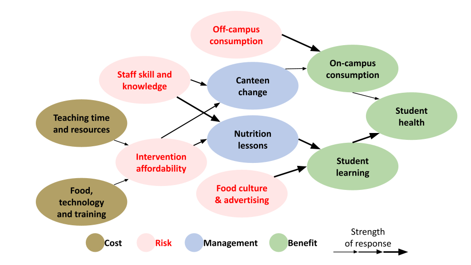

**Figure 1.** Conceptual model of school nutrition policy impacts. The diagram illustrates key variables influencing student health and learning outcomes in the context of school meal interventions. Variables are color-coded by type: management actions (blue) represent components that can be directly modified by policy (e.g. canteen change, nutrition lessons); costs (brown) reflect resource needs for implementation; risks (pink) represent contextual or behavioral barriers such as off-campus consumption or food culture and advertising; and benefits (green) are the desired outcomes, including on-campus consumption, student health, and student learning. Arrows indicate hypothesized causal relationships, with thicker arrows denoting stronger influence.

## Literature and policy review

We apply algorithmic support in R for comparing our conceptual model to the existing literature corpus, government policy documents and a qualitative assessment, using the `stringr` (Wickham 2025) and `bibtex` (Francois and Hernangómez 2023) packages for text processing and bibliography parsing. We apply these findings to systematically evaluate whether each component of our conceptual model is supported, refuted, missing from the literature and/or policy documents. We then synthesize this into a justified and adjusted version of the model (see [Literature and Policy Review for Nutrition interventions in Hanoi Schools](https://htmlpreview.github.io/?https://github.com/kimanh358/HUPH_decision_policy_nutrition/blob/main/lit_review.html)).

# Model update and Monte Carlo Simulation

We took all literatture and policy review findings into account and also talked to experts to update the model.

[figure not shown]

We ran the full model using Monte Carlo simulation to estimate the likely outcomes of different school nutrition policy configurations. All uncertain inputs were defined using probability distributions (e.g. truncated normal, normal, or uniform). Policy toggles, such as staff training and canteen monitoring, were included as binary variables with a 50% probability (10 to 90% chance of occurrence) to simulate diverse configurations. This allowed exploration of combined and independent effects of policy elements.

## Key Input Assumptions

All model inputs were modeled probabilistically based on expert judgment and literature estimates. See the script `school_policy_function.R` and input file `input_school_policy_post.csv` for full details.

We used a Monte Carlo simulation (Luedeling et al. 2024) to estimate the educational and health outcomes of school meal policy interventions. We ran the model 10,000 times to capture uncertainty across a wide range of possible scenarios.

## Comparative outcome distributions

We compare the distributions of the three discounted outcome variables directly. The Decision NPV integrates both health savings and education gains net of costs, while Net Health Benefit and Education Benefit represent the component contributions before estimating costs.

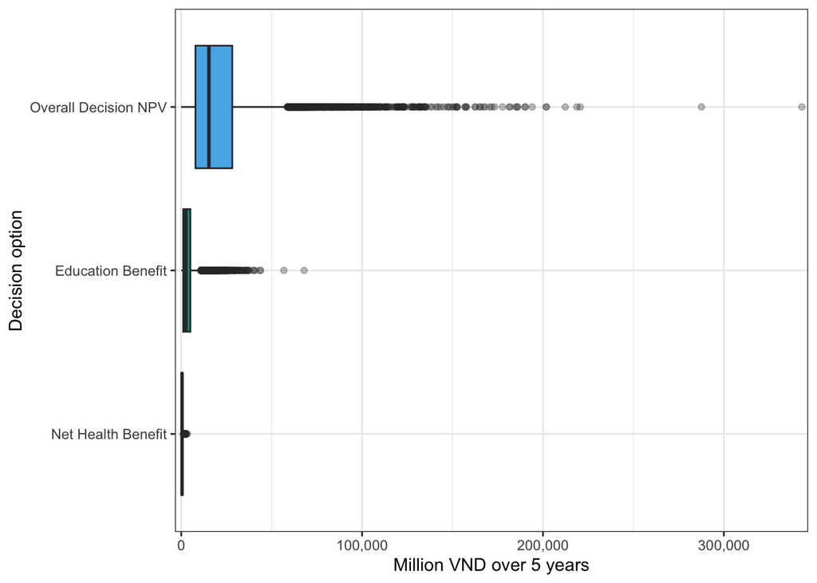

## Cashflow over the policy horizon

The plots below show how each outcome component accumulates year by year across all 10,000 simulations. The shaded band spans the 5th–95th percentile; the solid line is the median. Because `cashflow_policy` is the incremental cashflow (policy minus do-nothing), its median discounts to `decision_value`. `cashflow_health` and `cashflow_education` are the two additive benefit components before subtracting implementation costs.

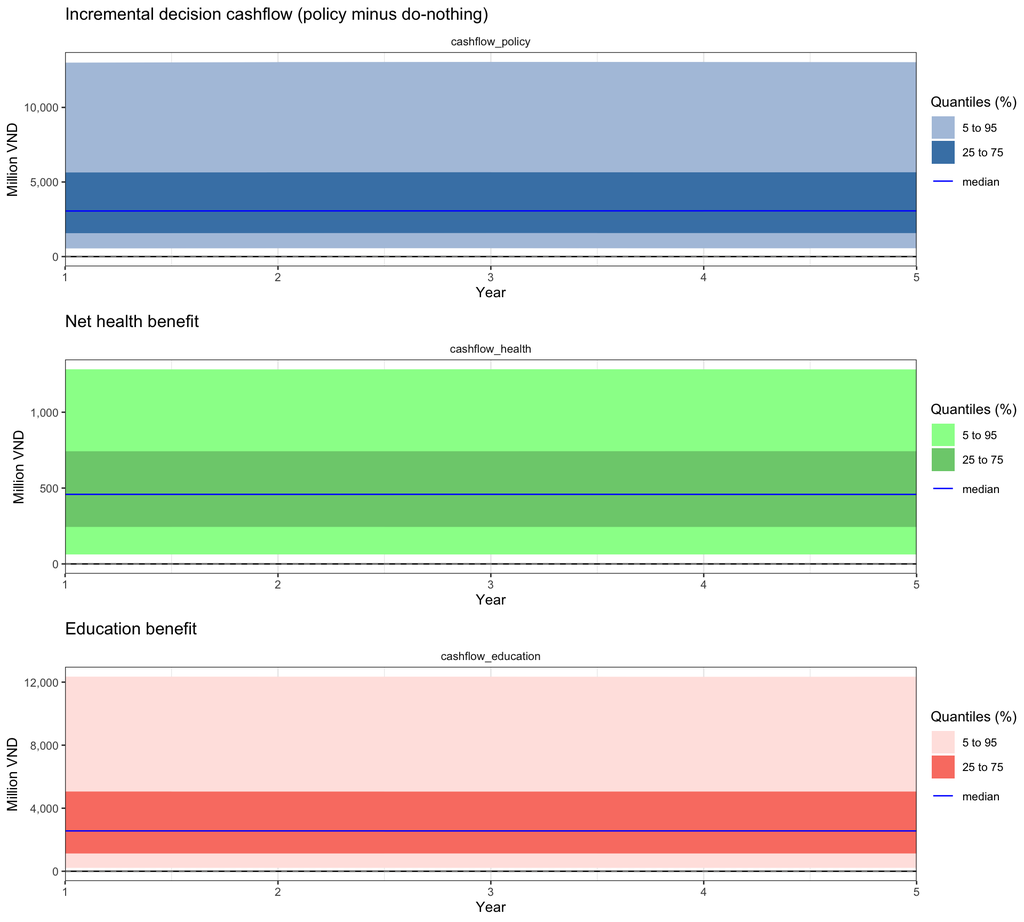

**Figure 3.** Year-by-year cashflows over the 5-year policy horizon. Each panel shows 10,000 simulation trajectories; shaded bands span the 5th–95th (outer) and 25th–75th (inner) percentile range; the solid line is the median. **Top:** incremental decision cashflow — the net gain of acting versus doing nothing, inclusive of all implementation costs. **Middle:** net health benefit (reduced diagnosis and treatment costs plus absenteeism savings). **Bottom:** education benefit (incremental learning value attributable to the intervention). The health and education panels sum to the gross policy benefit; subtracting implementation costs gives the top panel. Plots produced with `ggplot2` (Wickham, Chang, et al. 2026) and composited with `cowplot` (Wilke 2025).

## Distribution of NPV components by intervention

Each row is one intervention (active runs only). The three columns show the distribution of the **overall net** NPV, the **health** component, and the **education** component across all Monte Carlo runs. Visualised with `ggplot2` (Wickham, Chang, et al. 2026) and arranged with `cowplot` (Wilke 2025).

[figure not shown]

Overall our simulations show that implementation of the policy will have a positive effect on health and education.

# Comparing five actions

Next we look for formulations of school meal interventions that show the greatest influence on overall, health and education outcomes. Our model includes toggle variables to simulate the presence or absence of specific interventions. We can identify which combinations of actions appear in the most efficient scenarios.

## Mean decision value by action

We compare the mean net present value (NPV) of the policy decision across simulations where each intervention was present (toggle = 1) versus absent (toggle = 0).

Mean decision NPV (million VND) by intervention toggle

| Intervention | Mean NPV (off) | Mean NPV (on) | Difference |
| --- | --- | --- | --- |
| Food Safety Training | 20620 | 23732 | 3113 |
| Nutrition Training | 19740 | 24595 | 4856 |
| Physical Activity | 20438 | 23915 | 3477 |
| Menu Change to Meet RDA | 20373 | 23940 | 3568 |
| Limit Unhealthy Canteen Food | 20378 | 23900 | 3522 |

## Expected Value of Perfect Information (EVPI) analysis

Run Expected Value of Perfect Information (EVPI) analysis and save the result as `data_evpi.Rda`. We run `multi_EVPI` on the full input space `simulation_result$x` rather than just the toggles — the important uncertainty is in the effect-magnitude and cost parameters, not in whether each intervention is “on.”

```
## [1] 0
```

```
## [1] 0.0001179543
```

```
## [1] 0
```

For **net health benefits**, the EVPI is 0; for **education benefits**, the EVPI is 0; for the **composite decision value** (NPV), the EVPI is 0 million VND. A small residual uncertainty in the return in a minority of simulations produce outcomes close to break-even, and perfect information about those parameters could marginally improve the decision. Nevertheless, the magnitude is low relative to the median NPV, and the decision to implement remains robust. Together, these results suggest that further data collection is unlikely to change the policy recommendation, and the current evidence base is sufficient to proceed with the intervention.

# School-level expert health effect assessment

During expert elicitation, staff at each of the three study schools provided their own estimates, including student numbers, training costs, food environment conditions, BMI prevalence, and barriers to implementation.

To keep the health effect estimates internally consistent and comparable across schools, we retain the general pooled health parameters from `input_school_policy_post.csv` (disease diagnosis and treatment rates, cost per event, sick-day parameters). The school-specific contextual and cost variables are overlaid on top of this base, so each school’s simulation reflects its own food environment and operational costs while sharing a common health parameter set.

We run the full `school_policy_function` as a separate Monte Carlo for each school (5,000 runs), producing school-specific distributions of the net health benefit and showing the relative contribution of each of the five management options.

## Health and education benefit distributions and management option contributions

Boxplots show one management option (toggle-ON runs only). Only simulations where the option was active (toggle ≥ 0.5) are included. School color coding: **Dong Ngac A** (blue), **Dong Ngac B** (orange), **Duc Thang** (green). All three schools share the same pooled health and education effect parameters; differences across schools arise from their local food environment, BMI context, student numbers, and implementation costs.

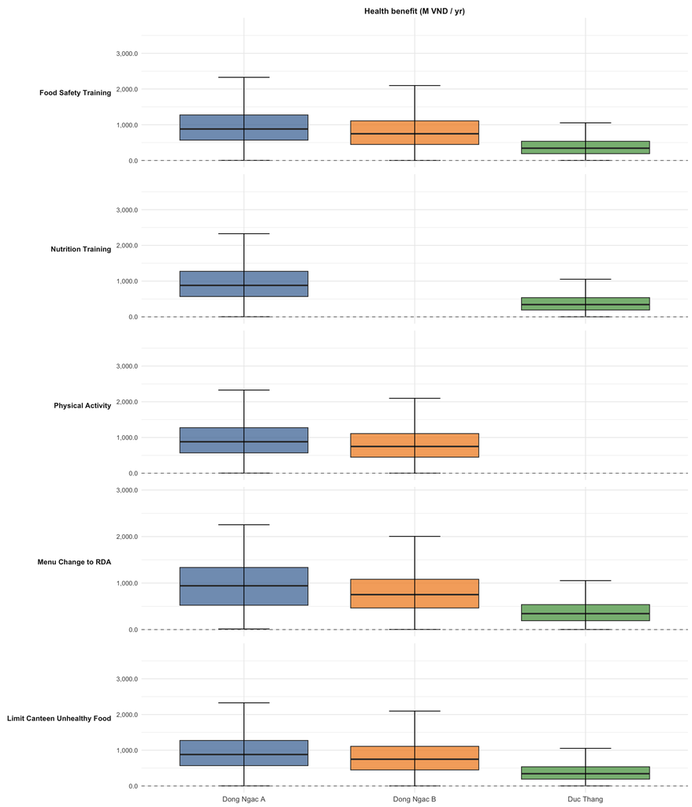

Mean and 90% confidence interval of outcome distributions by school (million VND, 5,000 Monte Carlo runs per school). ‘Combined’ pools all school simulations.

| School | Benefit | Mean (million VND) | Lower (5th percentile) | Upper (95th percentile) |
| --- | --- | --- | --- | --- |
| Dong Ngac A | Overall | 120,765.2 | 28,306.3 | 282,631.0 |
| Dong Ngac A | Health | 954.2 | 212.5 | 1,920.2 |
| Dong Ngac A | Education | 23,227.3 | 4,928.8 | 55,529.4 |
| Dong Ngac B | Overall | 56,642.2 | 18,048.8 | 120,707.5 |
| Dong Ngac B | Health | 820.3 | 157.4 | 1,694.3 |
| Dong Ngac B | Education | 10,581.7 | 3,112.6 | 23,389.5 |
| Duc Thang | Overall | 19,715.3 | 4,601.6 | 41,140.7 |
| Duc Thang | Health | 395.0 | 66.0 | 910.3 |
| Duc Thang | Education | 3,566.9 | 642.5 | 7,758.2 |
| Combined | Overall | 65,707.6 | 8,349.6 | 201,004.4 |
| Combined | Health | 723.2 | 106.6 | 1,679.4 |
| Combined | Education | 12,458.6 | 1,324.5 | 39,297.8 |

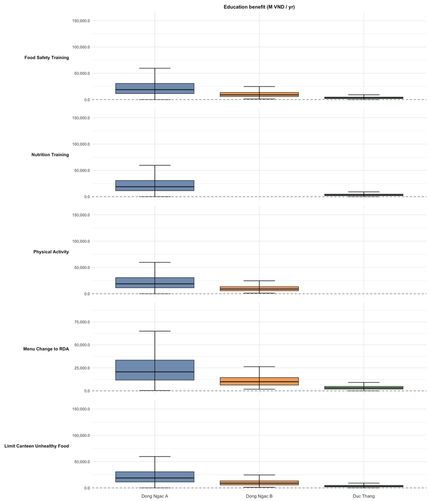

# Pareto analysis

Toggle comparisons cannot capture how actions interact when implemented together. In this model, benefits compound through intermediate variables, so the effective return of any action depends in part on which other actions are also active. A scenario with all five toggles on is not simply the sum of five individual differences. We use the Pareto analysis as a multi-objective approach to identify *combinations* that yield the most efficient outcomes. Data manipulation for the Pareto filter used `dplyr` (Wickham, François, et al. 2026); results are summarised in tables formatted with `knitr` (Xie 2025). It can also indicate where trade-offs arise between NPV, health, and education benefits. The Pareto front includes simulations that are not outperformed in all objectives by any other scenario. These are the most efficient configurations—improvements in one outcome would require trade-offs in others. We ran Pareto analysis across three dimensions: The economic return in the form of a discounted Net Present Value (NPV), health benefits and education benefits.

These findings highlight the existence of efficient policy options that cannot be improved in one objective without sacrificing another. Decision-makers can use this front to choose policies based on priorities — e.g., maximizing health benefits under a fixed cost constraint, or seeking the best ROI with acceptable health impacts.

## Plot Pareto optimal

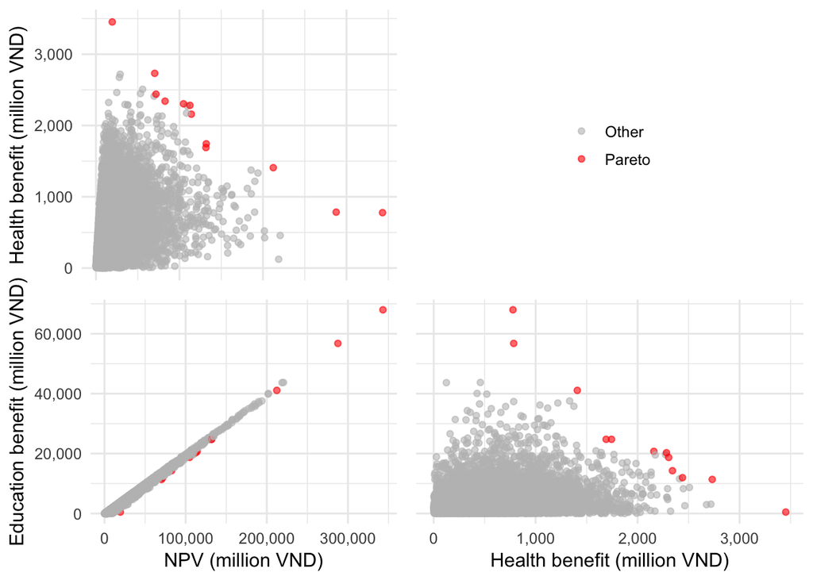

## Management options

Toggle Settings in Pareto-Optimal Simulations

|  | Mean_All | Mean_Pareto |
| --- | --- | --- |
| Physical Activity Training | 0.5 | 0.66 |
| Menu Change to Meet RDA | 0.5 | 0.61 |
| Limit Unhealthy Canteen Food | 0.5 | 0.61 |
| Food Safety Training | 0.5 | 0.60 |
| Nutrition Training | 0.5 | 0.58 |

## General variable assessment

We compared the mean values of all input variables between the full simulation set and the Pareto-optimal subset. The variables with the greatest deviations help identify factors that characterize efficient policy configurations.

The columns show the mean value of each input across all simulations (`Mean_All`) and across the Pareto-optimal subset (`Mean_Pareto`). Rows are ordered by the largest absolute difference between the two, highlighting the inputs most associated with efficient policy configurations. Variables where `Mean_Pareto` is notably higher or lower than `Mean_All` identify conditions that characterize the best-performing scenarios.

Mean input values across all simulations vs. Pareto-optimal simulations

|  | Mean_All | Mean_Pareto |
| --- | --- | --- |
| baseline_sick_days_per_student | 4.96 | 7.98 |
| student_performance_improvement | 0.30 | 0.46 |
| value_of_learning_per_student | 5.23 | 7.35 |
| value_per_sick_day_lost | 0.13 | 0.17 |
| staff_training_foodsafety_nutrition_effect | 0.50 | 0.68 |
| use_physical_activity | 0.50 | 0.66 |
| peer_influence_factor | 0.30 | 0.39 |
| training_costs_foodsafety_1st_year | 7.32 | 5.25 |
| overweight_diagnosis_risk_multiplier | 0.09 | 0.07 |
| overweight_treatment_risk_multiplier | 0.09 | 0.12 |
| staff_training_nutrition_effect | 0.50 | 0.62 |
| use_menu_change_rda | 0.50 | 0.61 |
| use_limit_unhealthy_canteen_food | 0.50 | 0.61 |
| use_staff_training_foodsafety | 0.50 | 0.60 |
| food_access_and_consumption_reduce_underweight | 0.38 | 0.30 |
| nutrition_status_bmi_high | 0.15 | 0.18 |
| unhealthy_canteen_foods | 0.21 | 0.17 |
| limit_unhealthy_canteen_food_nutrition_effect | 0.50 | 0.58 |
| training_costs_nutrition_annual | 5.63 | 6.59 |
| food_access_and_consumption_threshold | 0.20 | 0.17 |
| baseline_disease_diagnosis | 0.02 | 0.02 |
| underweight_treatment_risk_multiplier | 0.30 | 0.34 |
| use_staff_training_nutrition | 0.50 | 0.58 |
| change_menu_costs_annual | 5.98 | 6.81 |
| n_student | 1345.49 | 1532.19 |
| menu_change_rda_nutrition_effect | 0.50 | 0.56 |
| monitoring_canteen_cost | 25.28 | 22.53 |
| training_costs_foodsafety_annual | 5.65 | 5.04 |
| nutrition_status_bmi_low | 0.07 | 0.08 |
| n_reduce_disease_treatment | 0.02 | 0.02 |
| discount_rate | 0.03 | 0.03 |
| food_access_and_consumption_reduce_overweight | 0.37 | 0.40 |
| underweight_threshold | 0.30 | 0.27 |
| baseline_student_performance | 0.60 | 0.64 |
| physical_activity_effect | 0.50 | 0.54 |
| training_costs_nutrition_1st_year | 7.26 | 6.77 |
| unhealthy_school_gate_foods | 0.40 | 0.37 |
| underweight_diagnosis_risk_multiplier | 0.30 | 0.32 |
| overweight_threshold | 0.30 | 0.31 |
| baseline_disease_treatment | 0.05 | 0.05 |
| advertisement_exposure | 0.65 | 0.62 |
| CV_value | 0.15 | 0.16 |
| disease_diagnosis_cost | 0.03 | 0.03 |
| disease_treatment_cost | 0.03 | 0.03 |
| training_costs_physical_activity_annual | 5.71 | 5.80 |
| children_access_healthy_food | 0.85 | 0.86 |
| staff_knowledge_nutrition | 0.80 | 0.81 |
| children_consume_healthy_food | 0.83 | 0.84 |
| training_costs_physical_activity_1st_year | 7.23 | 7.16 |
| n_sick_days_avoided_per_student | 1.73 | 1.75 |
| resistance_child_preferences_attitude | 0.39 | 0.39 |
| n_reduce_disease_diagnosis | 0.02 | 0.02 |
| number_of_years | 5.00 | 5.00 |

Our analysis provides insight into how specific school nutrition policy components influence multiple objectives under uncertainty. The approach demonstrates how evidence-based modeling can inform practical decision-making, supporting the design of more effective and efficient interventions.

## References

Francois, Romain, and Diego Hernangómez. 2023. *Bibtex: Bibtex Parser*. https://github.com/ropensci/bibtex.

Luedeling, Eike, Lutz Goehring, Katja Schiffers, Cory Whitney, and Eduardo Fernandez. 2024. *decisionSupport: Quantitative Support of Decision Making Under Uncertainty*. http://www.worldagroforestry.org/.

Wickham, Hadley. 2025. *Stringr: Simple, Consistent Wrappers for Common String Operations*. https://stringr.tidyverse.org.

Wickham, Hadley, Winston Chang, Lionel Henry, et al. 2026. *Ggplot2: Create Elegant Data Visualisations Using the Grammar of Graphics*. https://ggplot2.tidyverse.org.

Wickham, Hadley, Romain François, Lionel Henry, Kirill Müller, and Davis Vaughan. 2026. *Dplyr: A Grammar of Data Manipulation*. https://dplyr.tidyverse.org.

Wickham, Hadley, Thomas Lin Pedersen, and Dana Seidel. 2025. *Scales: Scale Functions for Visualization*. https://scales.r-lib.org.

Wickham, Hadley, Davis Vaughan, and Maximilian Girlich. 2025. *Tidyr: Tidy Messy Data*. https://tidyr.tidyverse.org.

Wilke, Claus O. 2025. *Cowplot: Streamlined Plot Theme and Plot Annotations for Ggplot2*. https://wilkelab.org/cowplot/.

Xie, Yihui. 2025. *Knitr: A General-Purpose Package for Dynamic Report Generation in r*. https://yihui.org/knitr/.